# Modelagem de Séries Temporais com Python

## Python Sudeste 2018

### Wilson Freitas

## Wilson Freitas

- físico
- quant
- corredor
- padeiro

## Agenda

- Séries Temporais
- Processos Estocásticos Lineares Estacionários
- Modelos de Volatilidade

## O que são Séries Temporais?

Qualquer conjunto de dados ordenados no tempo

- Exemplos:
  - preços de ações na Bolsa de Valores
  - dados de tráfego do estado de São Paulo
  - registro de temperatura
  - Dados de GPS: posição, frequência cardíaca

# Como são modeladas séries temporais?

- Regressão
- Modelos ARIMA
- Modelos GARCH
- Modelos VAR/Cointegração
- Redes Neurais
  - multilayer perceptron
  - bayesian neural networks
  - radial basis functions
- Lógica Fuzzy
- K-nearest neighbor
- Support vector machines
- ...

# O que vamos fazer?

- Encontrar um modelo para a série de preços do dólar em reais $p_t$
- O modelo deve reproduzir as **propriedades estatíticas** da série de preços

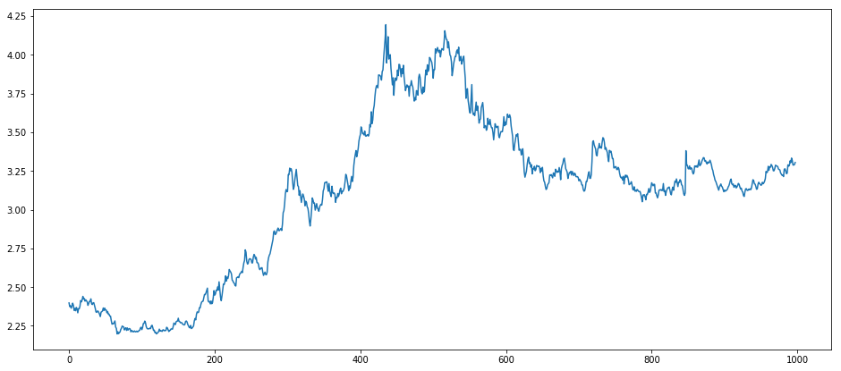

```python
import quandl
dol = quandl.get('BCB/1', start_date = '2014-01-01', end_date = '2017-12-21').reset_index(drop=True)
plt.plot(dol);
```

# A série de preços dá trabalho!

- A série de preços não é estacionária
- Os modelos de séries temporais são para séries estacionárias

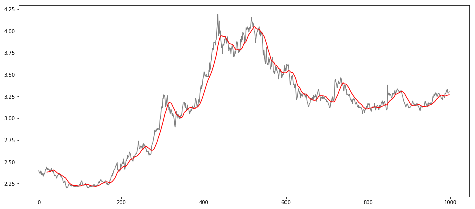

```python
r = dol.rolling(window=21)
plt.plot(dol, 'k-', alpha = 0.5)
plt.plot(r.mean(), 'r-');
```

# Vamos trabalhar com a variação dos preços

- A variação dos preços é *tipicamente* estacionária $x_t$

$$ \begin{split} x_t &= \log p_t - \log p_{t-1} \\ & = \log\left( \frac{p_t}{p_{t-1}} \right) \end{split} $$

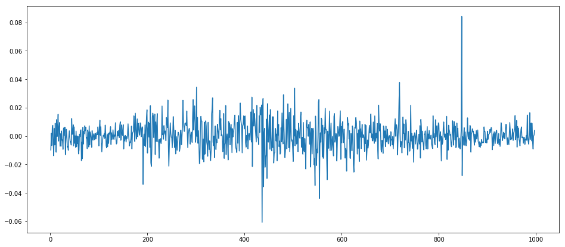

```python
dol_ret = np.log(dol).diff().dropna()
plt.plot(dol_ret);
```

## Voltando para os preços

Reconstruindo a série de preços $p_t$ a partir da série de retornos $x_t$.

$$ x_t = \log\left( \frac{p_t}{p_{t-1}} \right) \longrightarrow p_{t} = p_{t-1} \exp{x_t} $$

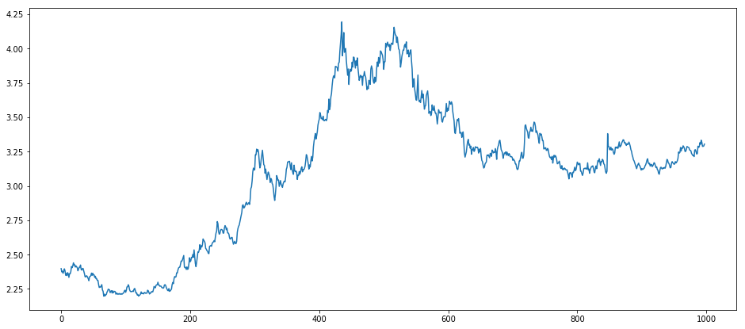

```python
#                       p_{t-1}        exp(x_t)
dol1 = np.cumprod(np.r_[dol.values[0], np.exp(dol_ret.values.reshape(len(dol_ret)))])
plt.plot(dol1);
```

# Histograma de $x_t$

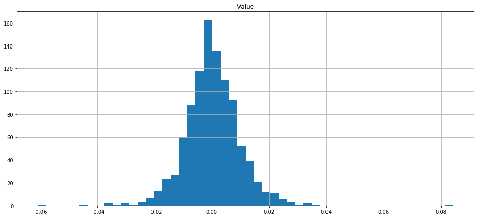

```python
dol_ret.hist(bins=50);
```

# Média Móvel de $x_t$

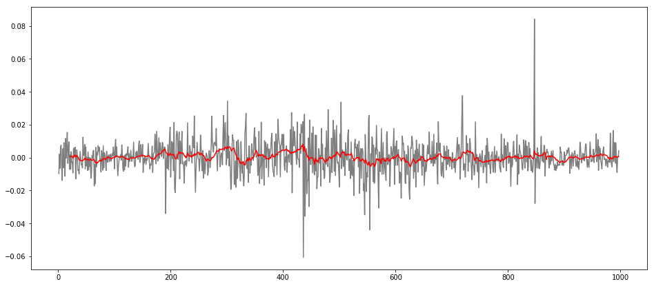

```python
r = dol_ret.rolling(window=21)
plt.plot(dol_ret, 'k-', alpha = 0.5)
plt.plot(r.mean(), 'r-');
```

# Desvio Padrão em Janela Móvel de $x_t$

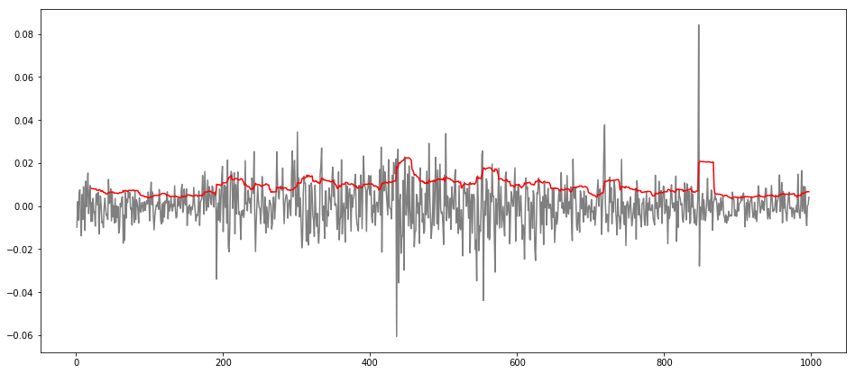

```python
plt.plot(dol_ret, 'k-', alpha = 0.5)
plt.plot(r.std(), 'r-');
```

# O que observamos olhando $x_t$?

- a média de $x_t$ varia muito pouco em torno de zero
- o desvio padrão de $x_t$ tem uma dinâmica

Vamos usar uma técninca para modelar as **propriedades estatísticas** de $x_t$.

## Vamos considerar o modelo abaixo para $x_t$

Estamos assumindo que o passado pode explicar o futuro.
$$ x_t = \mu + \phi_1 x_{t-1} + \epsilon_t $$

- Esse modelo descreve um **processo autoregressivo**
- É como um regressão de $x_t$ sobre o passado de $x_t$

# `statsmodels`

- Linear regression models
- Generalized linear models
- Discrete choice models
- Robust linear models
- Many models and functions for time series analysis
- Nonparametric estimators
- A collection of datasets for examples
- A wide range of statistical tests
- Input-output tools for producing tables in a number of formats (Text, LaTex, HTML) and for reading Stata files into NumPy and Pandas.
- Plotting functions
- Extensive unit tests to ensure correctness of results

fonte: http://statsmodels.sourceforge.net/

```python
import statsmodels.tsa as tsa
import statsmodels.api as sm
```

```python
model = sm.tsa.ARMA(dol_ret.as_matrix(), (1, 0)).fit(trend = 'c')
print(model.summary())
```

```
                              ARMA Model Results
==============================================================================
Dep. Variable:                      y   No. Observations:                  997
Model:                     ARMA(1, 0)   Log Likelihood                3196.990
Method:                       css-mle   S.D. of innovations              0.010
Date:                Fri, 30 Mar 2018   AIC                          -6387.980
Time:                        16:26:54   BIC                          -6373.266
Sample:                             0   HQIC                         -6382.387

==============================================================================
                 coef    std err          z      P>|z|      [0.025      0.975]
------------------------------------------------------------------------------
const          0.0003      0.000      1.030      0.303      -0.000       0.001
ar.L1.y        0.0071      0.032      0.223      0.824      -0.055       0.069
                                    Roots
=============================================================================
                 Real           Imaginary           Modulus         Frequency
-----------------------------------------------------------------------------
AR.1          141.6541           +0.0000j          141.6541            0.0000
-----------------------------------------------------------------------------
```

# Simulando $x_t$ com o modelo adotado

- Tendo os parâmetros do modelo, $\mu$ e $\phi$, podemos fazer simulações usando $x_t = \mu + \phi_1 x_{t-1} + \epsilon_t$

```python
model.params
```

```
array([ 0.00032177,  0.00705945])
```

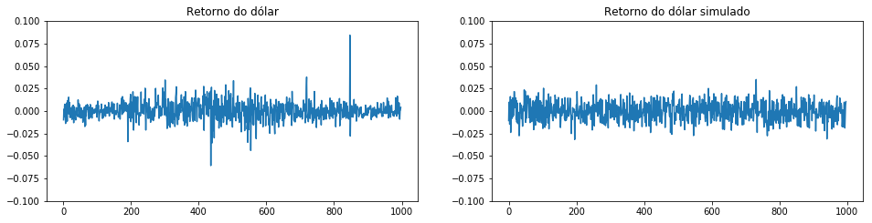

```python
dol_ar_proc = tsa.arima_process.ArmaProcess(np.r_[1, -model.params], [1])
dol_ar_sim = dol_ar_proc.generate_sample(len(dol_ret))*model.resid.std()
plot_two(dol_ret, dol_ar_sim, [-0.1,0.1], 'Retorno do dólar', 'Retorno do dólar simulado')
```

# Voltando para a série de $p_t$

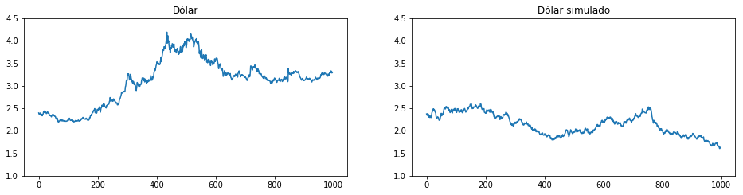

```python
dol1 = np.cumprod(np.r_[dol.values[1], np.exp(dol_ar_sim)])
plot_two(dol, dol1, [1,4.5], 'Dólar', 'Dólar simulado')
```

# Olhando os resíduos

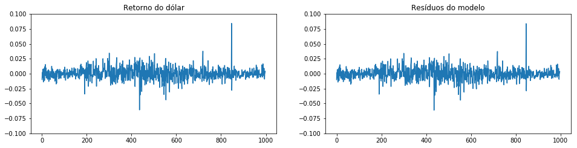

```python
plot_two(dol_ret, model.resid, [-0.1,0.1], 'Retorno do dólar', 'Resíduos do modelo')
```

## Vamos tentar algo diferente

- Sabendo que o desvio padrão tem uma dinâmica, vamos usar um modelo que possa descrever o desvio padrão.
- Os modelos da família GARCH podem fazer isso!

$$ x_t = \mu + \epsilon_t $$

onde

$$ \begin{align} \epsilon_t & = z_t \sigma_t \\ \sigma^2_t & = \omega + \alpha_1 e^2_{t-1} + \beta_1 \sigma^2_{t-1} \end{align} $$

- $z_t \sim N(0, 1)$.
- A variância do processo é um **processo autoregressivo**

# `arch`

The ARCH toolbox currently contains routines for

- Univariate volatility models
- Bootstrapping
- Multiple comparison procedures
- Unit root tests

fonte: http://arch.readthedocs.io/en/latest/

```python
from arch import arch_model
am = arch_model(dol_ret*100, p=1, q=1)
res = am.fit(disp='off')
print(res.summary())
```

```
                     Constant Mean - GARCH Model Results
==============================================================================
Dep. Variable:                  Value   R-squared:                      -0.000
Mean Model:             Constant Mean   Adj. R-squared:                 -0.000
Vol Model:                      GARCH   Log-Likelihood:               -1342.72
Distribution:                  Normal   AIC:                           2693.45
Method:            Maximum Likelihood   BIC:                           2713.06
                                        No. Observations:                  997
Date:                Fri, Mar 30 2018   Df Residuals:                      993
Time:                        16:26:55   Df Model:                            4
                                 Mean Model
===========================================================================
                 coef    std err          t      P>|t|     95.0% Conf. Int.
---------------------------------------------------------------------------
mu             0.0299  3.888e-02      0.769      0.442 [-4.632e-02,  0.106]
                              Volatility Model
===========================================================================
                 coef    std err          t      P>|t|     95.0% Conf. Int.
---------------------------------------------------------------------------
omega          0.0469  4.816e-02      0.974      0.330 [-4.748e-02,  0.141]
alpha[1]       0.1167  6.011e-02      1.941  5.228e-02 [-1.149e-03,  0.234]
beta[1]        0.8451  8.267e-02     10.223  1.571e-24    [  0.683,  1.007]
===========================================================================

Covariance estimator: robust
```

```python
def simulate_garch(params, nobs, var=0):
    e = np.random.randn(nobs)
    var = np.zeros(len(e)) + var
    x = np.zeros(len(e))

    for t in range(len(e)):
        var[t] = params[1] + params[2] * x[t-1]**2 + params[3] * var[t-1]
        x[t] = params[0] + e[t] * np.sqrt(var[t])

    return x
```

# Simulando $x_t$ com o modelo GARCH estimado

- Tendo os parâmetros do modelo, $\omega$, $\beta$ e $\alpha$, podemos fazer simulações de $x_t$ usando o modelo GARCH

```python
res.params
```

```
mu          0.029881
omega       0.046921
alpha[1]    0.116672
beta[1]     0.845103
Name: params, dtype: float64
```

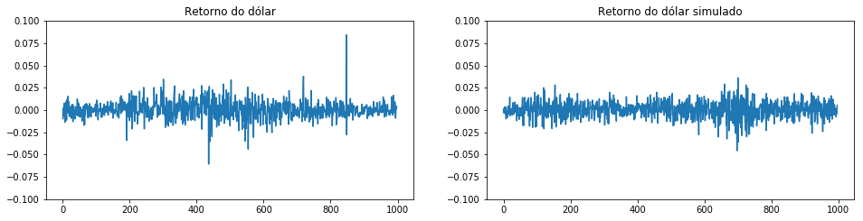

```python
dol_am_sim = simulate_garch(res.params, len(dol_ret))/100
plot_two(dol_ret, dol_am_sim, [-0.1,0.1], 'Retorno do dólar', 'Retorno do dólar simulado')
```

# Voltando para a série de $p_t$

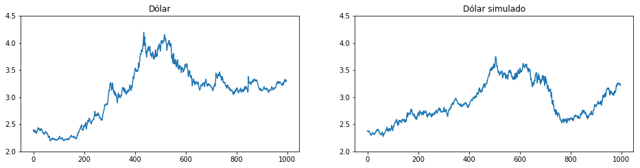

```python
dol1 = np.cumprod(np.r_[dol.values[1], np.exp(dol_am_sim)])
plot_two(dol, dol1, [2,4.5], 'Dólar', 'Dólar simulado')
```

# Olhando os resíduos

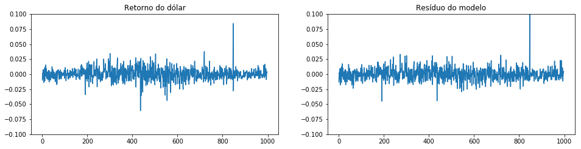

```python
plot_two(dol_ret, (res.resid/res.conditional_volatility)/100, [-0.1,0.1], 'Retorno do dólar', 'Resíduo do modelo')
```

# Simulando o futuro

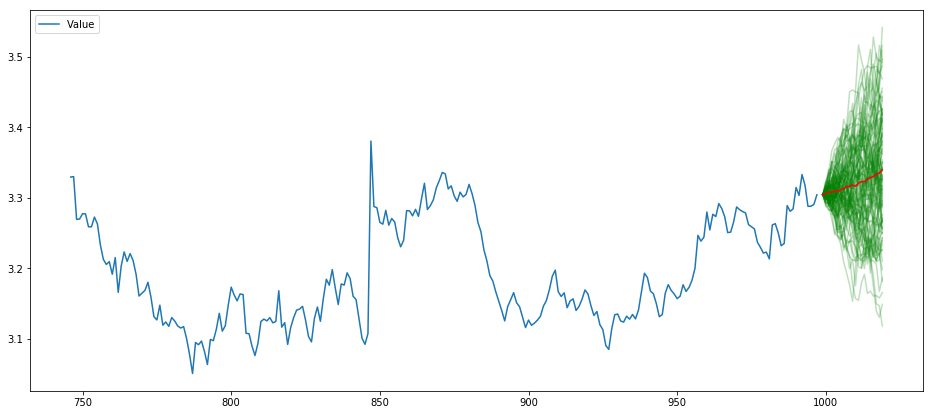

```python
dol.tail(252).plot()
paths = np.zeros((100,21))
for i in range(100):
    dol_am_sim = simulate_garch(res.params, 20)/100
    path = np.cumprod(np.r_[dol.values[-1], np.exp(dol_am_sim)])
    paths[i,:] = path
    plt.plot(range(999, 999+21), path, '-g', alpha = 0.25)
plt.plot(range(999, 999+21), np.mean(paths, 0), '-r');
```

## Conclusões

Aqui vimos um breve exemplo de como realizar Modelagem de Séries Temporais com Python.

A Modelagem de Séries Temporais é fundamental para a compreensão da **dinâmica** das séries temporais, particularmente utilizada para modelar séries financeiras.

A modelagem de séries temporais financeiras é utilizada para:

- Trading de Índices de Volatilidade
- Gestão de risco
- Apreçamento de derivativos financeiros
- Modelos de Volatilidade em Séries Intradiárias para avaliação de Risco Intradiário
- Modelos de Cointegração para trading de pares (*pairs trading*)
- Modelos de execução de ordens em condições heterogêneas

## Referências

- http://statsmodels.sourceforge.net/stable/
- https://github.com/bashtage/arch
- http://pandas.pydata.org/